# Libraries

```python
import numpy as np
from matplotlib import pyplot as plt
import seaborn as sns
import pandas as pd
import warnings
from sklearn.model_selection import train_test_split, GridSearchCV
from sklearn.preprocessing import StandardScaler
from sklearn.discriminant_analysis import LinearDiscriminantAnalysis, QuadraticDiscriminantAnalysis
from sklearn.naive_bayes import GaussianNB
from sklearn.ensemble import RandomForestClassifier, GradientBoostingClassifier
from sklearn.svm import SVC
from sklearn.neural_network import MLPClassifier
from sklearn.linear_model import LogisticRegression
from sklearn.metrics import roc_auc_score, accuracy_score, confusion_matrix, precision_score, recall_score, f1_score, classification_report
import pickle as pkl
import torch
import torch.nn as nn
import torch.optim as optim
from torch.utils.data import DataLoader, TensorDataset

my_seed = 56
```

# Tools

```python
def get_save_estimator(estimator, train_score, test_score, name, save=True, folder="params"):
    if save:
        with open(f"{folder}/"+name+"_best_estimator.pkl", 'wb') as f:
            pkl.dump(estimator, f)
        with open(f"{folder}/"+name+"_best_train_score.pkl", 'wb') as f:
            pkl.dump(train_score, f)
        with open(f"{folder}/"+name+"_best_test_score.pkl", 'wb') as f:
            pkl.dump(test_score, f)
    else:
        with open(f"{folder}/"+name+"_best_estimator.pkl", 'rb') as f:
            estimator = pkl.load(f)
        with open(f"{folder}/"+name+"_best_train_score.pkl", 'rb') as f:
            train_score = pkl.load(f)
        with open(f"{folder}/"+name+"_best_test_score.pkl", 'rb') as f:
            test_score = pkl.load(f)

    return estimator, train_score, test_score
```

```python
def get_acc_f1_prec_rec(y_true, y_pred):
    acc = accuracy_score(y_true, y_pred)
    f1 = f1_score(y_true, y_pred, average='micro')
    prec = precision_score(y_true, y_pred, average='micro')
    rec = recall_score(y_true, y_pred, average='micro')
    return acc, f1, prec, rec
```

# 1. Dataset Description

## 1.3. Loading the data

#### 1.3.1. Load the data with np.load("filename.npz") and store the different matrices in memory (for instance in variables x1,y1 for Pima data and x2,y2,xt2,yt2 for digits data). For the digits dataset,it is better to perform one simple pre-processing that scales the values between [0, 1] by dividing the data matrix by 255

For Pima Dataset :

```python
pima_data = np.load("pima.npz")
pima_data.files
```

```
['xall', 'yall', 'varnames']
```

```python
x1 = pima_data['xall']
y1 = pima_data['yall']
pima_vars = pima_data['varnames']

print("X shape:", x1.shape)
print("Y shape:", y1.shape)
print("Variables:", *pima_vars)
```

```
X shape: (709, 8)
Y shape: (709,)
Variables: Pregnancies Glucose BloodPressure SkinThickness Insulin BMI DiabetesPedigreeFunction Age
```

For Digits Dataset :

```python
digits_data = np.load("digits.npz")
digits_data.files
```

```
['xt', 'yt', 'y', 'x']
```

```python
xt2 = digits_data['xt']
yt2 = digits_data['yt']
x2 = digits_data['x']
y2 = digits_data['y']

print("X train shape:", x2.shape, "| Y train shape:", y2.shape)
print("X test shape:", xt2.shape, "| Y test shape:", yt2.shape)
```

```
X train shape: (3000, 784) | Y train shape: (3000, 1)
X test shape: (1500, 784) | Y test shape: (1500, 1)
```

We rescale pixel values between 0 and 1 by dividing them by 255.0. We do this for both training and testing data.

```python
x2 = x2/255
xt2 = xt2/255
```

#### 1.3.2. Do a quick look at the data, compute the mean values for each variable and interpret it.

For Pima Dataset :

```python
pd.DataFrame(x1, columns=pima_vars).describe().round(2)
```

|  | Pregnancies | Glucose | BloodPressure | SkinThickness | Insulin | BMI | DiabetesPedigreeFunction | Age |
| --- | --- | --- | --- | --- | --- | --- | --- | --- |
| count | 709.00 | 709.00 | 709.00 | 709.00 | 709.00 | 709.00 | 709.00 | 709.00 |
| mean | 3.75 | 121.61 | 69.64 | 20.77 | 80.53 | 32.45 | 0.47 | 33.02 |
| std | 3.34 | 30.49 | 18.14 | 15.90 | 112.68 | 6.95 | 0.33 | 11.67 |
| min | 0.00 | 44.00 | 0.00 | 0.00 | 0.00 | 18.20 | 0.08 | 21.00 |
| 25% | 1.00 | 99.00 | 64.00 | 0.00 | 0.00 | 27.50 | 0.24 | 24.00 |
| 50% | 3.00 | 117.00 | 72.00 | 23.00 | 40.00 | 32.30 | 0.37 | 29.00 |
| 75% | 6.00 | 141.00 | 80.00 | 32.00 | 130.00 | 36.60 | 0.63 | 40.00 |
| max | 17.00 | 199.00 | 122.00 | 99.00 | 744.00 | 67.10 | 2.42 | 81.00 |

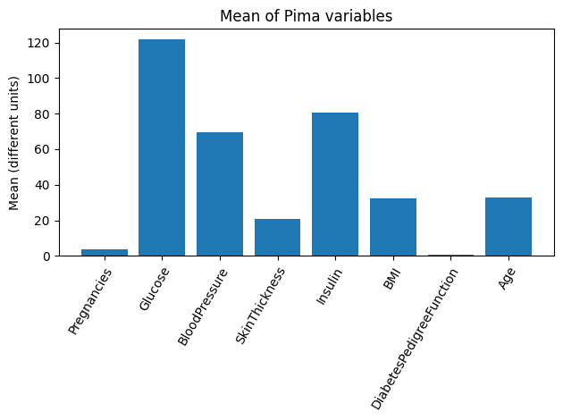

```python
plt.bar(np.arange(8), np.mean(x1, axis=0))
plt.xticks(np.arange(8), pima_vars, rotation=60, ha='right', rotation_mode='anchor')
plt.ylabel("Mean (different units)")
plt.title("Mean of Pima variables")
plt.tight_layout()
```

```python
print("Pima Labels:", np.unique(y1))
```

```
Pima Labels: [-1  1]
```

For Digits Dataset :

Example of a digit :

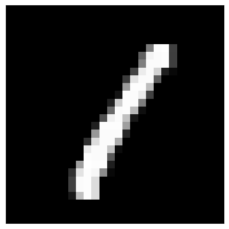

```python
fig = plt.imshow(x2[0].reshape(28, 28), cmap='gray')
fig.axes.get_xaxis().set_visible(False)
fig.axes.get_yaxis().set_visible(False)
plt.show()
```

Now, let's visualize the mean values for each variable (i.e. each pixel) to obtain a mean digit :

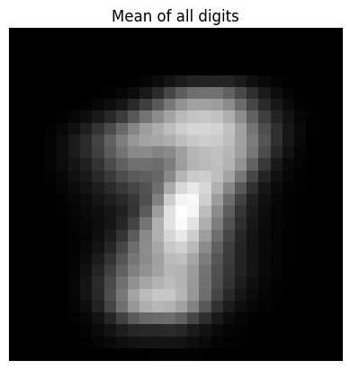

```python
fig = plt.imshow(x2.mean(axis=0).reshape(28, 28), cmap='gray')
fig.axes.get_xaxis().set_visible(False)
fig.axes.get_yaxis().set_visible(False)
plt.title("Mean of all digits")
plt.show()
```

```python
print("All different digits Labels:", np.unique(y2))
```

```
All different digits Labels: [1 7 8]
```

# 2. Predicting Diabetes on Pima Dataset

## 2.1. Know the data

#### 2.1.1. Visualize the data as scatterplots between pairs of variables (where the color is the class)

```python
df1 = pd.concat((pd.DataFrame(x1, columns=pima_vars), pd.DataFrame(y1, columns=["y"])), axis=1)
```

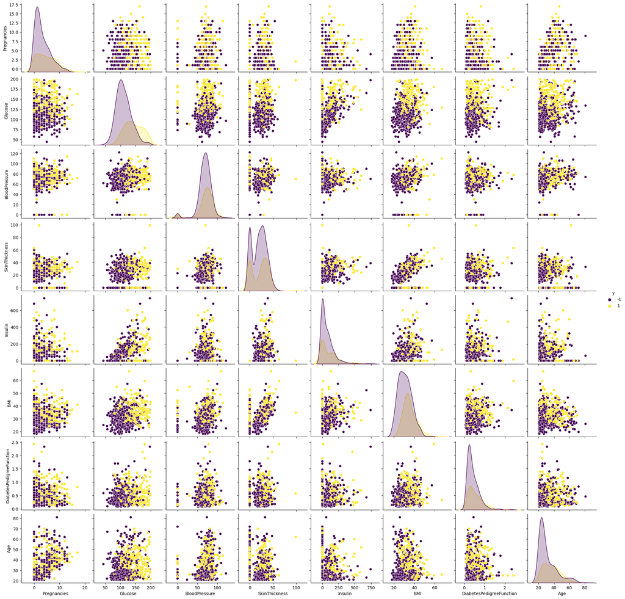

```python
with warnings.catch_warnings():
    warnings.simplefilter('ignore')
    sns.pairplot(df1, hue="y", palette="viridis")
    plt.show()
```

#### 2.1.2. What are the variables that seem to help predict the class? Do those variable make sense from a medical perspective ?

From visualizing variable combinations, we notice that some variables are more important than others to predict the class. For instance, if we consider all combinations of glucose feature with other variables, we notice that the two classes (non-diabetic and diabetic) are very well separated meaning that glucose is a very important feature to predict the class. On the other hand, considering the Skin Thickness feature with respect to other variables, the two classes are not separated in a satisfactory manner. This means that this feature is not as important to predict the class. Now that we have the intuition, let's classify variables in a naive way.

Most Important variables (naive approach):

- Glucose
- Insulin
- BMI
- DiabetesPedigreeFunction

Less Important variables (naive approach):

- Thickness of Skin

From a medical perspective, this in sensible because glucose and insulin are the main indicators of diabetes. As BMI measures body fat, it also makes sense that it is a good predictor of the class. Finally, DiabetesPedigreeFunction is a function indicating diabetes likelihood depending on the subject's age and his/her diabetic family history making it a relevant feature.

#### 2.1.3. Split the data in training/test by keeping n = 300 samples for training/validation and the remaining for test

```python
x1_train, x1_test, y1_train, y1_test = train_test_split(x1, y1, train_size=300, random_state=my_seed)
```

#### 2.1.4. Do the feature have similar variances/scaling? Is that a problem ?

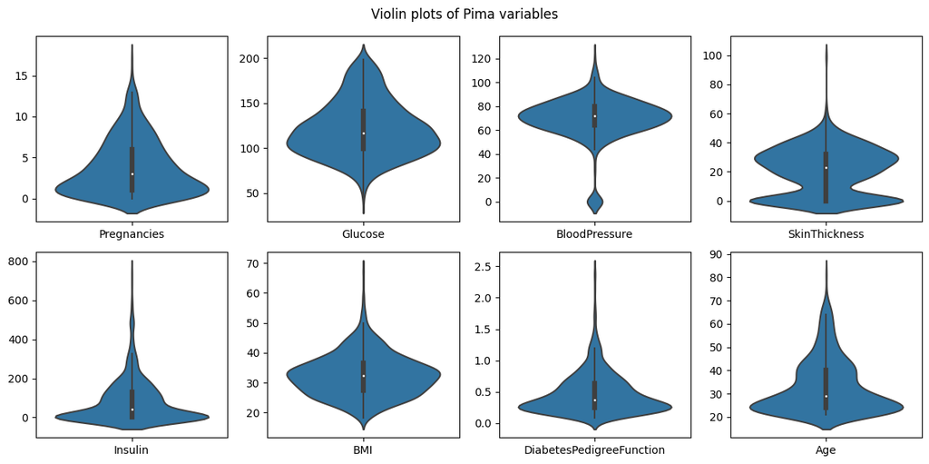

```python
f, axes = plt.subplots(2, 4, figsize=(12, 6))
for i, var in enumerate(pima_vars):
    warnings.simplefilter('ignore')
    sns.violinplot(df1[var], ax=axes[i//4, i%4])
    axes[i//4, i%4].set_xticklabels(labels=[var])
f.suptitle("Violin plots of Pima variables")
plt.tight_layout()
```

From the plots above, we notice very different variances between features. We can confirm this by looking at numerical values of variances for each feature :

```python
pd.DataFrame(x1, columns=pima_vars).describe().round(2).loc["std"]
```

```
Pregnancies                   3.34
Glucose                      30.49
BloodPressure                18.14
SkinThickness                15.90
Insulin                     112.68
BMI                           6.95
DiabetesPedigreeFunction      0.33
Age                          11.67
Name: std, dtype: float64
```

#### 2.1.5. Apply a standardization to the training and test data (StandardScaler).

```python
std_scaler = StandardScaler()
x1_train = std_scaler.fit_transform(x1_train)
x1_test = std_scaler.transform(x1_test)
```

```python
pd.DataFrame(x1_train, columns=pima_vars).describe().round(2).loc["std"]
```

```
Pregnancies                 1.0
Glucose                     1.0
BloodPressure               1.0
SkinThickness               1.0
Insulin                     1.0
BMI                         1.0
DiabetesPedigreeFunction    1.0
Age                         1.0
Name: std, dtype: float64
```

Our variables are now scaled and have similar variances.

## 2.2. Bayesian Descision and linear classification

#### 2.2.1. Train a Linear Discriminant Analysis (LDA) classifier with the default parameters, compute its accuracy and AUC on the test data (LinearDiscriminantAnalysis,roc_auc_score). Note that in order to compute the AUC you will need to compute the score with est.predict_proba and keep the second column (probability of the class 1).

```python
lda = LinearDiscriminantAnalysis(solver="lsqr")
lda.fit(x1_train, y1_train)
pred = lda.predict(x1_test)
pred_prob = lda.predict_proba(x1_test)

print("Test ROC score:", round(roc_auc_score(y1_test, pred_prob[:, 1]), 2), "| Test Accuracy score:",  round(accuracy_score(y1_test, pred), 2))
```

```
Test ROC score: 0.84 | Test Accuracy score: 0.78
```

#### 2.2.2. Perform a cross validation GridSearchCV) for the parameters of the method (shrinkage). Does the validation leads to better performance? What is the optimal value for the parameter?

```python
params = {
    "shrinkage": np.linspace(0, 1, 50)
}

gs = GridSearchCV(lda, params, scoring="roc_auc")
res = gs.fit(x1_train, y1_train)
```

```python
lda = gs.best_estimator_
```

```python
pred = lda.predict(x1_test)
pred_prob = lda.predict_proba(x1_test)

lda_acc_train = accuracy_score(y1_train, lda.predict(x1_train))
lda_roc_train = roc_auc_score(y1_train, lda.predict_proba(x1_train)[:, 1])
lda_acc_test= accuracy_score(y1_test, pred)
lda_roc_test = roc_auc_score(y1_test, pred_prob[:, 1])

print("Train ROC score:", round(lda_roc_train, 2), "| Train Accuracy score:",  round(lda_acc_train, 2))
print("Test ROC score:", round(lda_roc_test, 2), "| Test Accuracy score:",  round(lda_acc_test, 2))
```

```
Train ROC score: 0.86 | Train Accuracy score: 0.8
Test ROC score: 0.85 | Test Accuracy score: 0.77
```

Performances haven't changed significantly. Roc have increased of 1% while accurancy decreased of 1%. This makes sense because we are using roc as performance metric for the grid search cross validation.

#### 2.2.3. Train a Quadratic Discriminant Analysis (QDA) classifier with the default parameters, compute its accuracy and AUC on the test data (QuadraticDiscriminantAnalysis). Is the performance better than LDA?

```python
qda = QuadraticDiscriminantAnalysis()
qda.fit(x1_train, y1_train)
pred = qda.predict(x1_test)
pred_prob = qda.predict_proba(x1_test)

print("Test ROC score:", round(roc_auc_score(y1_test, pred_prob[:, 1]), 2), "| Test Accuracy score:",  round(accuracy_score(y1_test, pred), 2))
```

```
Test ROC score: 0.84 | Test Accuracy score: 0.76
```

Performances are slightly worse than LDA for accuracy (-2%) and equivalent for Roc.

#### 2.2.4. Perform a cross validation for the parameters of the method (reg_param). Does the validation leads to better performance? What is the optimal value for the parameter.

```python
params = {
    "reg_param": np.linspace(0, 1, 50)
}

gs = GridSearchCV(qda, params)
res = gs.fit(x1_train, y1_train)
```

```python
qda = gs.best_estimator_
```

```python
pred = qda.predict(x1_test)
pred_prob = qda.predict_proba(x1_test)

qda_acc_train = accuracy_score(y1_train, qda.predict(x1_train))
qda_roc_train = roc_auc_score(y1_train, qda.predict_proba(x1_train)[:, 1])
qda_acc_test= accuracy_score(y1_test, pred)
qda_roc_test = roc_auc_score(y1_test, pred_prob[:, 1])

print("Train ROC score:", round(qda_roc_train, 2), "| Train Accuracy score:",  round(qda_acc_train, 2))
print("Test ROC score:", round(qda_roc_test, 2), "| Test Accuracy score:",  round(qda_acc_test, 2))
```

```
Train ROC score: 0.85 | Train Accuracy score: 0.79
Test ROC score: 0.85 | Test Accuracy score: 0.78
```

#### 2.2.5. Train a Gaussian Naive Bayes (NB) classifier (GaussianNB). What is its performance with respect to QDA and LDA?

```python
gnb = GaussianNB()
gnb.fit(x1_train, y1_train)

pred = gnb.predict(x1_test)
pred_prob = gnb.predict_proba(x1_test)

gnb_acc_train = accuracy_score(y1_train, gnb.predict(x1_train))
gnb_roc_train = roc_auc_score(y1_train, gnb.predict_proba(x1_train)[:, 1])
gnb_acc_test = accuracy_score(y1_test, pred)
gnb_roc_test = roc_auc_score(y1_test, pred_prob[:, 1])

pd.DataFrame({
    "Train Accuracy": [lda_acc_train, qda_acc_train, gnb_acc_train],
    "Test Accuracy": [lda_acc_test, qda_acc_test, gnb_acc_test],
    "Train ROC": [lda_roc_train, qda_roc_train, gnb_roc_train],
    "Test ROC": [lda_roc_test, qda_roc_test, gnb_roc_test]
}, index=["LDA", "QDA", "GNB"]).round(2)
```

|  | Train Accuracy | Test Accuracy | Train ROC | Test ROC |
| --- | --- | --- | --- | --- |
| LDA | 0.80 | 0.77 | 0.86 | 0.85 |
| QDA | 0.79 | 0.78 | 0.85 | 0.85 |
| GNB | 0.78 | 0.77 | 0.83 | 0.84 |

Its performances are slightly worse than LDA and QDA for both accuracy and Roc. However, we should take into account that LDA and QDA have been fine-tuned while NB has not.

#### 2.2.6. Train a Logistic regression classifier (LogisticRegression) with the default parameters. Compute its performance and compare it to the previous classifiers.

```python
logreg = LogisticRegression()
logreg.fit(x1_train, y1_train)

pred = logreg.predict(x1_test)
pred_prob = logreg.predict_proba(x1_test)

logreg_acc_train = accuracy_score(y1_train, logreg.predict(x1_train))
logreg_roc_train = roc_auc_score(y1_train, logreg.predict_proba(x1_train)[:, 1])
logreg_acc_test = accuracy_score(y1_test, pred)
logreg_roc_test = roc_auc_score(y1_test, pred_prob[:, 1])

pd.DataFrame({
    "Train Accuracy": [lda_acc_train, qda_acc_train, gnb_acc_train, logreg_acc_train],
    "Test Accuracy": [lda_acc_test, qda_acc_test, gnb_acc_test, logreg_acc_test],
    "Train ROC": [lda_roc_train, qda_roc_train, gnb_roc_train, logreg_roc_train],
    "Test ROC": [lda_roc_test, qda_roc_test, gnb_roc_test, logreg_roc_test]
}, index=["LDA", "QDA", "GNB", "LogReg"]).round(2)
```

|  | Train Accuracy | Test Accuracy | Train ROC | Test ROC |
| --- | --- | --- | --- | --- |
| LDA | 0.80 | 0.77 | 0.86 | 0.85 |
| QDA | 0.79 | 0.78 | 0.85 | 0.85 |
| GNB | 0.78 | 0.77 | 0.83 | 0.84 |
| LogReg | 0.80 | 0.79 | 0.86 | 0.84 |

#### 2.2.7. Perform a a cross validation for the parameters of the model (C) by setting the penalization to L1. Is the model sparse? What variables were removed from the model? Is the classifier performing well?

```python
params = {
    "C": np.logspace(-3, 3, 50)
}

gs = GridSearchCV(logreg, params, scoring="roc_auc")
res = gs.fit(x1_train, y1_train)

logreg = gs.best_estimator_
```

- Glucose
- BMI
- Diabetes Pedigree Function

On the other hand, 2 variables have been almost fully removed from the model :

- Skin Thickness
- Insulin

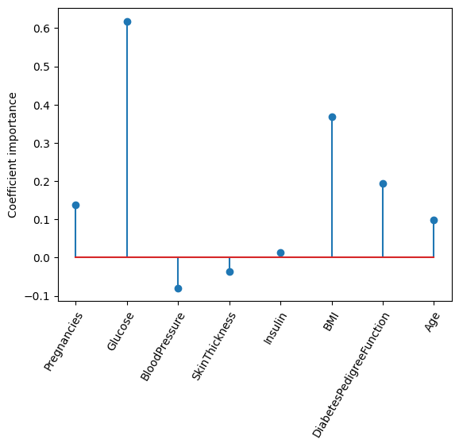

```python
plt.stem(logreg.coef_.flatten())
plt.xticks(np.arange(8), pima_vars, rotation=60, ha="right", rotation_mode="anchor")
plt.ylabel("Coefficient importance")
plt.show()
```

```python
pred = logreg.predict(x1_test)
pred_prob = logreg.predict_proba(x1_test)


logreg_acc_train = accuracy_score(y1_train, logreg.predict(x1_train))
logreg_roc_train = roc_auc_score(y1_train, logreg.predict_proba(x1_train)[:, 1])
Logreg_acc_test = accuracy_score(y1_test, pred)
Logreg_roc_test = roc_auc_score(y1_test, pred_prob[:, 1])

pd.DataFrame({
    "Train Accuracy": [lda_acc_train, qda_acc_train, gnb_acc_train, logreg_acc_train],
    "Test Accuracy": [lda_acc_test, qda_acc_test, gnb_acc_test, logreg_acc_test],
    "Train ROC": [lda_roc_train, qda_roc_train, gnb_roc_train, logreg_roc_train],
    "Test ROC": [lda_roc_test, qda_roc_test, gnb_roc_test, logreg_roc_test]
}, index=["LDA", "QDA", "GNB", "LogReg"]).round(2)
```

|  | Train Accuracy | Test Accuracy | Train ROC | Test ROC |
| --- | --- | --- | --- | --- |
| LDA | 0.80 | 0.77 | 0.86 | 0.85 |
| QDA | 0.79 | 0.78 | 0.85 | 0.85 |
| GNB | 0.78 | 0.77 | 0.83 | 0.84 |
| LogReg | 0.80 | 0.79 | 0.86 | 0.84 |

#### 2.2.9. Interpret the separability of the sample in the predicted score space by plotting histograms for the samples for each class in 1D.

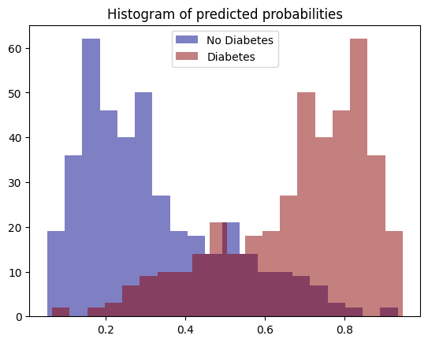

```python
plt.hist(pred_prob[:, 1], bins=20, color="darkblue", alpha=0.5)
plt.hist(pred_prob[:, 0], bins=20, color="darkred", alpha=0.5)
plt.title("Histogram of predicted probabilities")
plt.legend(["No Diabetes", "Diabetes"])
plt.show()
```

#### 2.2.10. Interpret the weight for a good linear model. What is the effect of each variable on the risk of diabetes? Does it make medical sense?

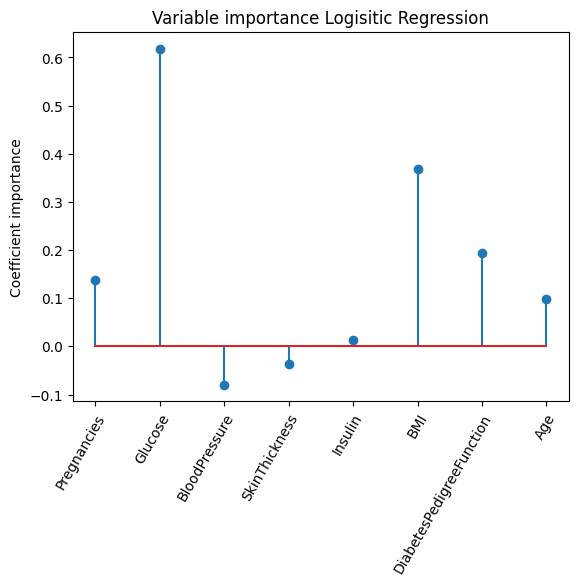

```python
plt.stem(logreg.coef_.flatten())
plt.xticks(np.arange(8), pima_vars, rotation=60, ha="right", rotation_mode="anchor")
plt.ylabel("Coefficient importance")
plt.title("Variable importance Logisitic Regression")
plt.show()
```

As we can see from the figure above, the most important variables are (ranked by importance) :

- Glucose
- BMI
- Diabetes Pedigree Function

From a medical perspective, this is sensible :

- Glucose is tighly correlated to diabetes.
- BMI is a good indicator of body fat and consequently of diabetes (carefull to differentiate diabetes types).
- Diabetes Pedigree Function is a function indicating diabetes likelihood depending on the subject's age and his/her diabetic family history making it a relevant feature.

## 2.3. Non linear methods

```python
save = False
```

### 2.3.1. Random Forest Classifier

#### 2.3.1.1. Fit the model with the default parameters and compute its prediction performance. Is it better than a linear estimator?

```python
rf = RandomForestClassifier(random_state=my_seed)
rf.fit(x1_train, y1_train.reshape(-1))

rf_pred_test = rf.predict(x1_test)
rf_pred_prob_test = rf.predict_proba(x1_test)

rf_acc_train = accuracy_score(y1_train, rf.predict(x1_train))
rf_roc_train = roc_auc_score(y1_train, rf.predict_proba(x1_train)[:, 1])
rf_acc_test = accuracy_score(y1_test, rf_pred_test)
rf_roc_test = roc_auc_score(y1_test, rf_pred_prob_test[:, 1])

pd.DataFrame({
    "Train Accuracy": [logreg_acc_train, rf_acc_train],
    "Test Accuracy": [logreg_acc_test, rf_acc_test],
    "Train ROC": [logreg_roc_train, rf_roc_train],
    "Test ROC": [logreg_roc_test, rf_roc_test]
}, index=["LogReg", "RF"]).round(2)
```

|  | Train Accuracy | Test Accuracy | Train ROC | Test ROC |
| --- | --- | --- | --- | --- |
| LogReg | 0.8 | 0.79 | 0.86 | 0.84 |
| RF | 1.0 | 0.76 | 1.00 | 0.84 |

Random forest (non-tuned) is slightly worse than Logistic Regression (fine-tuned) for both accuracy and Roc. However, we notice that it overfits the training data much more than Logistic Regression.

#### 2.3.1.2. Do a quick validation of some of the important parameters (manually or with sklearn classes). Can you find a better performance?

```python
if save:
    params = {
        "n_estimators": [20, 25, 30, 35],
        "criterion": ["gini", "entropy", "logloss"],
        "max_depth": [None, 5, 6, 7],
        "min_samples_leaf": [10, 15, 20],
        "max_features": [None, 2, 3, 4]
    }

    gs = GridSearchCV(rf, params, scoring="roc_auc")
    res = gs.fit(x1_train, y1_train.reshape(-1))
    rf = gs.best_estimator_
```

```python
if save:
    with open('params/rf_best_estimator.pkl', 'wb') as f:
        pkl.dump(rf, f)
else:
    with open('params/rf_best_estimator.pkl', 'rb') as f:
        rf = pkl.load(f)
```

```python
rf_pred_test = rf.predict(x1_test)
rf_pred_prob_test = rf.predict_proba(x1_test)

rf_acc_train = accuracy_score(y1_train, rf.predict(x1_train))
rf_roc_train = roc_auc_score(y1_train, rf.predict_proba(x1_train)[:, 1])
rf_acc_test = accuracy_score(y1_test, rf_pred_test)
rf_roc_test = roc_auc_score(y1_test, rf_pred_prob_test[:, 1])

pd.DataFrame({
    "Train Accuracy": [logreg_acc_train, rf_acc_train],
    "Test Accuracy": [logreg_acc_test, rf_acc_test],
    "Train ROC": [logreg_roc_train, rf_roc_train],
    "Test ROC": [logreg_roc_test, rf_roc_test]
}, index=["LogReg", "RF"]).round(2)
```

|  | Train Accuracy | Test Accuracy | Train ROC | Test ROC |
| --- | --- | --- | --- | --- |
| LogReg | 0.80 | 0.79 | 0.86 | 0.84 |
| RF | 0.83 | 0.75 | 0.92 | 0.83 |

The model still overfits but much less than previously. In addition, its performances are unchanged but still inferior to Logistic Regression.

```python
rf.get_params()
```

```
{'bootstrap': True,
 'ccp_alpha': 0.0,
 'class_weight': None,
 'criterion': 'entropy',
 'max_depth': 5,
 'max_features': 2,
 'max_leaf_nodes': None,
 'max_samples': None,
 'min_impurity_decrease': 0.0,
 'min_samples_leaf': 15,
 'min_samples_split': 2,
 'min_weight_fraction_leaf': 0.0,
 'n_estimators': 30,
 'n_jobs': None,
 'oob_score': False,
 'random_state': 56,
 'verbose': 0,
 'warm_start': False}
```

### 2.3.2. Support Vector Machine Classifier

#### 2.3.2.1. Fit the model with the default parameters and compute its prediction performance. Is it better than a linear estimator?

```python
svc = SVC(probability=True, random_state=my_seed)
svc.fit(x1_train, y1_train.reshape(-1))

svc_pred_test = svc.predict(x1_test)
svc_pred_prob_test = svc.predict_proba(x1_test)

svc_acc_train = accuracy_score(y1_train, svc.predict(x1_train))
svc_roc_train = roc_auc_score(y1_train, svc.predict_proba(x1_train)[:, 1])
svc_acc_test = accuracy_score(y1_test, svc_pred_test)
svc_roc_test = roc_auc_score(y1_test, svc_pred_prob_test[:, 1])

pd.DataFrame({
    "Train Accuracy": [logreg_acc_train, rf_acc_train, svc_acc_train],
    "Test Accuracy": [logreg_acc_test, rf_acc_test, svc_acc_test],
    "Train ROC": [logreg_roc_train, rf_roc_train, svc_roc_train],
    "Test ROC": [logreg_roc_test, rf_roc_test, svc_roc_test]
}, index=["LogReg", "RF", "SVC"]).round(2)
```

|  | Train Accuracy | Test Accuracy | Train ROC | Test ROC |
| --- | --- | --- | --- | --- |
| LogReg | 0.80 | 0.79 | 0.86 | 0.84 |
| RF | 0.83 | 0.75 | 0.92 | 0.83 |
| SVC | 0.86 | 0.76 | 0.91 | 0.85 |

SVC untuned performs better around as good as Logistic Regression (fine-tuned) for both accuracy and Roc. However, we notice that it overfits the training data slightly more than Logistic Regression.

#### 2.3.2.2. Do a quick validation of some of the important parameters (manually or with sklearn classes). Can you find a better performance?

```python
if save:
    params = {
        "C": np.logspace(-3, 3, 5),
        "gamma": np.logspace(-3, 3, 5),
        "kernel": ["rbf", "sigmoid"],
        "degree": [2, 3, 4],
        "coef0": [0, 1, 2],
        "shrinking": [True, False]
    }

    gs = GridSearchCV(svc, params, scoring="roc_auc")
    res = gs.fit(x1_train, y1_train.reshape(-1))
    svc = gs.best_estimator_
```

```python
if save:
    with open('params/svc_best_estimator.pkl', 'wb') as f:
        pkl.dump(svc, f)
else:
    with open('params/svc_best_estimator.pkl', 'rb') as f:
        svc = pkl.load(f)
```

```python
svc_pred_test = svc.predict(x1_test)
svc_pred_prob_test = svc.predict_proba(x1_test)

svc_acc_train = accuracy_score(y1_train, svc.predict(x1_train))
svc_roc_train = roc_auc_score(y1_train, svc.predict_proba(x1_train)[:, 1])
svc_acc_test = accuracy_score(y1_test, svc_pred_test)
svc_roc_test = roc_auc_score(y1_test, svc_pred_prob_test[:, 1])

pd.DataFrame({
    "Train Accuracy": [logreg_acc_train, rf_acc_train, svc_acc_train],
    "Test Accuracy": [logreg_acc_test, rf_acc_test, svc_acc_test],
    "Train ROC": [logreg_roc_train, rf_roc_train, svc_roc_train],
    "Test ROC": [logreg_roc_test, rf_roc_test, svc_roc_test]
}, index=["LogReg", "RF", "SVC"]).round(2)
```

|  | Train Accuracy | Test Accuracy | Train ROC | Test ROC |
| --- | --- | --- | --- | --- |
| LogReg | 0.80 | 0.79 | 0.86 | 0.84 |
| RF | 0.83 | 0.75 | 0.92 | 0.83 |
| SVC | 0.80 | 0.76 | 0.86 | 0.84 |

With this setting, SVC performs almost as good as Logistic Regression (-3% on test accuracy) but it doesn't overfitting as before.

```python
svc.get_params()
```

```
{'C': 1.0,
 'break_ties': False,
 'cache_size': 200,
 'class_weight': None,
 'coef0': 1,
 'decision_function_shape': 'ovr',
 'degree': 2,
 'gamma': 0.03162277660168379,
 'kernel': 'sigmoid',
 'max_iter': -1,
 'probability': True,
 'random_state': 56,
 'shrinking': True,
 'tol': 0.001,
 'verbose': False}
```

### 2.3.3. Multi-layer Perceptron Classifier

#### 2.3.3.1. Fit the model with the default parameters and compute its prediction performance. Is it better than a linear estimator?

```python
mlp = MLPClassifier(random_state=my_seed)
mlp.fit(x1_train, y1_train.reshape(-1))

mlp_pred_test = mlp.predict(x1_test)
mlp_pred_prob_test = mlp.predict_proba(x1_test)

mlp_acc_train = accuracy_score(y1_train, mlp.predict(x1_train))
mlp_roc_train = roc_auc_score(y1_train, mlp.predict_proba(x1_train)[:, 1])
mlp_acc_test = accuracy_score(y1_test, mlp_pred_test)
mlp_roc_test = roc_auc_score(y1_test, mlp_pred_prob_test[:, 1])

pd.DataFrame({
    "Train Accuracy": [logreg_acc_train, rf_acc_train, svc_acc_train, mlp_acc_train],
    "Test Accuracy": [logreg_acc_test, rf_acc_test, svc_acc_test, mlp_acc_test],
    "Train ROC": [logreg_roc_train, rf_roc_train, svc_roc_train, mlp_roc_train],
    "Test ROC": [logreg_roc_test, rf_roc_test, svc_roc_test, mlp_roc_test]
}, index=["LogReg", "RF", "SVC", "MLP"]).round(2)
```

|  | Train Accuracy | Test Accuracy | Train ROC | Test ROC |
| --- | --- | --- | --- | --- |
| LogReg | 0.80 | 0.79 | 0.86 | 0.84 |
| RF | 0.83 | 0.75 | 0.92 | 0.83 |
| SVC | 0.80 | 0.76 | 0.86 | 0.84 |
| MLP | 0.84 | 0.76 | 0.92 | 0.84 |

Default MLP performs as good as fine-tuned SVC on test but if overfits the training data much more.

#### 2.3.3.2. Do a quick validation of some of the important parameters (manually or with sklearn classes). Can you find a better performance?

```python
if save:
    params = {
        "hidden_layer_sizes": [(32, 32, 16), (32, 32, 16, 16)],
        "activation": ["identity", "relu"],
        "solver": ["lbfgs", "sgd", "adam"],
        "alpha": np.logspace(-4, -2, 3),
        "learning_rate": ["constant", "invscµaling", "adaptive"]
    }

    gs = GridSearchCV(mlp, params, scoring="roc_auc")
    res = gs.fit(x1_train, y1_train.reshape(-1))
    mlp = gs.best_estimator_
```

```python
if save:
    with open('params/mlp_best_estimator.pkl', 'wb') as f:
        pkl.dump(mlp, f)
else:
    with open('params/mlp_best_estimator.pkl', 'rb') as f:
        mlp = pkl.load(f)
```

```python
mlp_pred_test = mlp.predict(x1_test)
mlp_pred_prob_test = mlp.predict_proba(x1_test)

mlp_acc_train = accuracy_score(y1_train, mlp.predict(x1_train))
mlp_roc_train = roc_auc_score(y1_train, mlp.predict_proba(x1_train)[:, 1])
mlp_acc_test = accuracy_score(y1_test, mlp_pred_test)
mlp_roc_test = roc_auc_score(y1_test, mlp_pred_prob_test[:, 1])

pd.DataFrame({
    "Train Accuracy": [logreg_acc_train, rf_acc_train, svc_acc_train, mlp_acc_train],
    "Test Accuracy": [logreg_acc_test, rf_acc_test, svc_acc_test, mlp_acc_test],
    "Train ROC": [logreg_roc_train, rf_roc_train, svc_roc_train, mlp_roc_train],
    "Test ROC": [logreg_roc_test, rf_roc_test, svc_roc_test, mlp_roc_test]
}, index=["LogReg", "RF", "SVC", "MLP"]).round(2)
```

|  | Train Accuracy | Test Accuracy | Train ROC | Test ROC |
| --- | --- | --- | --- | --- |
| LogReg | 0.80 | 0.79 | 0.86 | 0.84 |
| RF | 0.83 | 0.75 | 0.92 | 0.83 |
| SVC | 0.80 | 0.76 | 0.86 | 0.84 |
| MLP | 0.81 | 0.78 | 0.86 | 0.85 |

Thanks to the fine-tuning, MLP performs better than all other models (+1% on roc score on test set). Overfitting is still present but much less than before.

```python
mlp.get_params()
```

```
{'activation': 'identity',
 'alpha': 0.0001,
 'batch_size': 'auto',
 'beta_1': 0.9,
 'beta_2': 0.999,
 'early_stopping': False,
 'epsilon': 1e-08,
 'hidden_layer_sizes': (32, 32, 16),
 'learning_rate': 'constant',
 'learning_rate_init': 0.001,
 'max_fun': 15000,
 'max_iter': 200,
 'momentum': 0.9,
 'n_iter_no_change': 10,
 'nesterovs_momentum': True,
 'power_t': 0.5,
 'random_state': 56,
 'shuffle': True,
 'solver': 'sgd',
 'tol': 0.0001,
 'validation_fraction': 0.1,
 'verbose': False,
 'warm_start': False}
```

### 2.3.4. Gradient Boosting Classifier

#### 2.3.4.1. Fit the model with the default parameters and compute its prediction performance. Is it better than a linear estimator?

```python
gbc = GradientBoostingClassifier(random_state=my_seed)
gbc.fit(x1_train, y1_train.reshape(-1))

gbc_pred_test = gbc.predict(x1_test)
gbc_pred_prob_test = gbc.predict_proba(x1_test)

gbc_acc_train = accuracy_score(y1_train, gbc.predict(x1_train))
gbc_roc_train = roc_auc_score(y1_train, gbc.predict_proba(x1_train)[:, 1])
gbc_acc_test = accuracy_score(y1_test, gbc_pred_test)
gbc_roc_test = roc_auc_score(y1_test, gbc_pred_prob_test[:, 1])

pd.DataFrame({
    "Train Accuracy": [logreg_acc_train, rf_acc_train, svc_acc_train, mlp_acc_train, gbc_acc_train],
    "Test Accuracy": [logreg_acc_test, rf_acc_test, svc_acc_test, mlp_acc_test, gbc_acc_test],
    "Train ROC": [logreg_roc_train, rf_roc_train, svc_roc_train, mlp_roc_train, gbc_roc_train],
    "Test ROC": [logreg_roc_test, rf_roc_test, svc_roc_test, mlp_roc_test, gbc_roc_test]
}, index=["LogReg", "RF", "SVC", "MLP", "GBC"]).round(2)
```

|  | Train Accuracy | Test Accuracy | Train ROC | Test ROC |
| --- | --- | --- | --- | --- |
| LogReg | 0.80 | 0.79 | 0.86 | 0.84 |
| RF | 0.83 | 0.75 | 0.92 | 0.83 |
| SVC | 0.80 | 0.76 | 0.86 | 0.84 |
| MLP | 0.81 | 0.78 | 0.86 | 0.85 |
| GBC | 0.99 | 0.77 | 1.00 | 0.81 |

We notice that Gradient Boosting Classifier dangerously overfits the training data. It means that we should make the model less complex with the use of hyperparameters.

#### 2.3.4.2. Do a quick validation of some of the important parameters (manually or with sklearn classes). Can you find a better performance?

```python
if save:
    params = {
        "loss": ["log_loss", "exponential"],
        "learning_rate": np.logspace(-4, -2, 3),
        "criterion": ["friedman_mse", "squarred_error"],
        "n_estimators": [20, 25, 30],
        "max_depth": [3, 4, 5],
        "min_samples_leaf": [15, 20, 25],
        "max_features": [None, 2, 3]
    }

    gs = GridSearchCV(gbc, params, scoring="roc_auc")
    res = gs.fit(x1_train, y1_train.reshape(-1))
    gbc = gs.best_estimator_
```

```python
if save:
    with open('params/gbc_best_estimator.pkl', 'wb') as f:
        pkl.dump(gbc, f)
else:
    with open('params/gbc_best_estimator.pkl', 'rb') as f:
        gbc = pkl.load(f)
```

```python
gbc_pred_test = gbc.predict(x1_test)
gbc_pred_prob_test = gbc.predict_proba(x1_test)

gbc_acc_train = accuracy_score(y1_train, gbc.predict(x1_train))
gbc_roc_train = roc_auc_score(y1_train, gbc.predict_proba(x1_train)[:, 1])
gbc_acc_test = accuracy_score(y1_test, gbc_pred_test)
gbc_roc_test = roc_auc_score(y1_test, gbc_pred_prob_test[:, 1])

pd.DataFrame({
    "Train Accuracy": [logreg_acc_train, rf_acc_train, svc_acc_train, mlp_acc_train, gbc_acc_train],
    "Test Accuracy": [logreg_acc_test, rf_acc_test, svc_acc_test, mlp_acc_test, gbc_acc_test],
    "Train ROC": [logreg_roc_train, rf_roc_train, svc_roc_train, mlp_roc_train, gbc_roc_train],
    "Test ROC": [logreg_roc_test, rf_roc_test, svc_roc_test, mlp_roc_test, gbc_roc_test]
}, index=["LogReg", "RF", "SVC", "MLP", "GBC"]).round(2)
```

|  | Train Accuracy | Test Accuracy | Train ROC | Test ROC |
| --- | --- | --- | --- | --- |
| LogReg | 0.80 | 0.79 | 0.86 | 0.84 |
| RF | 0.83 | 0.75 | 0.92 | 0.83 |
| SVC | 0.80 | 0.76 | 0.86 | 0.84 |
| MLP | 0.81 | 0.78 | 0.86 | 0.85 |
| GBC | 0.67 | 0.65 | 0.92 | 0.82 |

```python
gbc.get_params()
```

```
{'ccp_alpha': 0.0,
 'criterion': 'friedman_mse',
 'init': None,
 'learning_rate': 0.001,
 'loss': 'exponential',
 'max_depth': 4,
 'max_features': 2,
 'max_leaf_nodes': None,
 'min_impurity_decrease': 0.0,
 'min_samples_leaf': 20,
 'min_samples_split': 2,
 'min_weight_fraction_leaf': 0.0,
 'n_estimators': 25,
 'n_iter_no_change': None,
 'random_state': 56,
 'subsample': 1.0,
 'tol': 0.0001,
 'validation_fraction': 0.1,
 'verbose': 0,
 'warm_start': False}
```

## 2.4. Comparision and interpretation

#### 2.4.1. Collect the test performances for all methods investigated above in a table (in a dataframe and printing it for instance). Which methods work the best in practice?

```python
pd.DataFrame({
    "Train Accuracy": [logreg_acc_train, rf_acc_train, svc_acc_train, mlp_acc_train, gbc_acc_train],
    "Test Accuracy": [logreg_acc_test, rf_acc_test, svc_acc_test, mlp_acc_test, gbc_acc_test],
    "Train ROC": [logreg_roc_train, rf_roc_train, svc_roc_train, mlp_roc_train, gbc_roc_train],
    "Test ROC": [logreg_roc_test, rf_roc_test, svc_roc_test, mlp_roc_test, gbc_roc_test]
}, index=["LogReg", "RF", "SVC", "MLP", "GBC"]).round(2)
```

|  | Train Accuracy | Test Accuracy | Train ROC | Test ROC |
| --- | --- | --- | --- | --- |
| LogReg | 0.80 | 0.79 | 0.86 | 0.84 |
| RF | 0.83 | 0.75 | 0.92 | 0.83 |
| SVC | 0.80 | 0.76 | 0.86 | 0.84 |
| MLP | 0.81 | 0.78 | 0.86 | 0.85 |
| GBC | 0.67 | 0.65 | 0.92 | 0.82 |

#### 2.4.2. Which model is best from a medical/practical perspective? Do we need non-linearity in this applica-tion?

For medical application, we would prefer an explainable model. In this case Logistic Regression with L1 regularization is working well and doesn't overfit the data so it's a good candidate. However, MLP is performing better and is not overfitting the data so it's also a good candidate even though it isn't explainable.

#### 2.4.3. For the best model, compute the confusion matrix for the test data. What is the false negative rate (FNR) (FN/(FN+TP)) for this classifier? Is it good for this kind of applications?

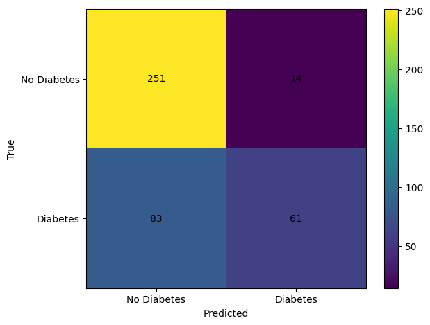

```python
plt.imshow(confusion_matrix(y1_test, logreg.predict(x1_test)))
for i in range(2):
    for j in range(2):
        plt.text(j, i, confusion_matrix(y1_test, logreg.predict(x1_test))[i, j], ha="center", va="center")
plt.xticks([0, 1], ["No Diabetes", "Diabetes"])
plt.yticks([0, 1], ["No Diabetes", "Diabetes"])
plt.xlabel("Predicted")
plt.ylabel("True")
plt.colorbar()
plt.tight_layout()
```

Here the false negative rate is : $FNR = \frac{FN}{(FN+TP)} = \frac{83}{83+61} = 0.57 = 57\%$

The false negative rate is very high. Such a False Negative Rate is relatively bad as it indicates the probability of telling someone that he is healthy while he actually suffers from diabetes. This kind of error could lead to people dying so it has to be avoided by all means. This error is most likely due to class imbalance as you can see below :

```python
class_perc = {i:str(round(np.sum(y1_train == i)/y1_train.shape[0]*100, 2))+"%" for i in np.unique(y1_train)}
print("Non-Diabetes:", class_perc[-1], "| Diabetes:", class_perc[1])
```

```
Non-Diabetes: 67.33% | Diabetes: 32.67%
```

#### 2.4.4. Since a false negative can have an important medical impact, propose a new threshold for the predicted score that leads to a FNR of less that 10% (this can be done by changing manually the value of the intercept_ in the trained classifier).

```python
intercepts = np.linspace(-5, 5, 20)
FNR = lambda conf_mat: conf_mat[1, 0]/(conf_mat[1, 0]+conf_mat[1, 1])

for intercept in intercepts:
    logreg.intercept_ = intercept
    conf_mat = confusion_matrix(y1_train, logreg.predict(x1_train))
    if FNR(conf_mat) < 0.1:
        found_intercept = intercept
        found_conf_mat = conf_mat
        break
print("Intercept:", round(found_intercept, 2), "| FNR:", round(FNR(found_conf_mat), 2))
```

```
Intercept: 0.26 | FNR: 0.09
```

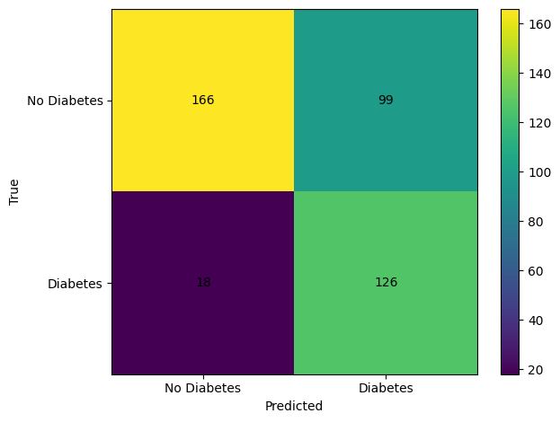

```python
plt.imshow(confusion_matrix(y1_test, logreg.predict(x1_test)))
for i in range(2):
    for j in range(2):
        plt.text(j, i, confusion_matrix(y1_test, logreg.predict(x1_test))[i, j], ha="center", va="center")
plt.xticks([0, 1], ["No Diabetes", "Diabetes"])
plt.yticks([0, 1], ["No Diabetes", "Diabetes"])
plt.xlabel("Predicted")
plt.ylabel("True")
plt.colorbar()
plt.tight_layout()
```

Now the false negative rate is : $FNR = \frac{FN}{(FN+TP)} = \frac{18}{18+126} = 12.5\%$ which is much better than before and close to the 10% threshold.

# 3. Predicting Classes for Digits Dataset

## 3.1. Evaluate the different supervised methods

```python
save = False
```

### 3.1.1. Linear Discriminant Analysis

#### 3.1.1.1. Fit the model with the default parameters and compute its prediction performance (accuracy on test data).

```python
lda = LinearDiscriminantAnalysis(solver="lsqr")
lda.fit(x2, y2)

lda_pred_train = lda.predict(x2)
lda_pred_test = lda.predict(xt2)

pd.DataFrame({
    "Train Accuracy": [accuracy_score(y2, lda_pred_train)],
    "Test Accuracy": [accuracy_score(yt2, lda_pred_test)]
}, index=["LDA"]).round(2)
```

|  | Train Accuracy | Test Accuracy |
| --- | --- | --- |
| LDA | 0.98 | 0.93 |

It looks like default LDA slightly overfits the training data. It still performs well on test.

#### 3.1.1.2. Do a quick validation of some of the important parameters (manually or with sklearn classes) to get a better performance if possible.

```python
if save:
    params = {
        "shrinkage": np.linspace(0, 1, 50)
    }

    gs = GridSearchCV(lda, params, scoring="accuracy")
    res = gs.fit(x2, y2)

    lda = gs.best_estimator_

    lda_pred_train = lda.predict(x2)
    lda_pred_test = lda.predict(xt2)

    lda_acc_train = accuracy_score(y2, lda_pred_train)
    lda_acc_test = accuracy_score(yt2, lda_pred_test)
```

#### 3.1.1.3. Store the model and the accuracy for the best parameter configuration.

```python
lda, lda_acc_train, lda_acc_test = get_save_estimator(lda, lda_acc_train, lda_acc_test, "lda", save=save, folder="digits_params")
```

```python
pd.DataFrame({
    "Train Accuracy": [lda_acc_train],
    "Test Accuracy": [lda_acc_test]
}, index=["LDA"]).round(2)
```

|  | Train Accuracy | Test Accuracy |
| --- | --- | --- |
| LDA | 0.96 | 0.95 |

Overfitting has been almost completely removed. Test accuracy has increased by 2% while training accuracy has decreased by 2%. This is excellent as it indicates that the model generalizes better.

### 3.1.2. Logistic Regression

#### 3.1.2.1. Fit the model with the default parameters and compute its prediction performance (accuracy on test data).

```python
logreg = LogisticRegression()
logreg.fit(x2, y2)

logreg_pred_train = logreg.predict(x2)
logreg_pred_test = logreg.predict(xt2)

logreg_acc_train = accuracy_score(y2, logreg_pred_train)
logreg_acc_test = accuracy_score(yt2, logreg_pred_test)

pd.DataFrame({
    "Train Accuracy": [lda_acc_train, logreg_acc_train],
    "Test Accuracy": [lda_acc_test, logreg_acc_test]
}, index=["LDA", "LogReg"]).round(2)
```

|  | Train Accuracy | Test Accuracy |
| --- | --- | --- |
| LDA | 0.96 | 0.95 |
| LogReg | 1.00 | 0.97 |

#### 3.1.2.2. Do a quick validation of some of the important parameters (manually or with sklearn classes) to get a better performance if possible.

```python
if save:
    params = {
        "C": np.logspace(-3, 3, 50)
    }

    gs = GridSearchCV(logreg, params, scoring="accuracy")
    res = gs.fit(x2, y2)

    logreg = gs.best_estimator_

    logreg_pred_train = logreg.predict(x2)
    logreg_pred_test = logreg.predict(xt2)

    logreg_acc_train = accuracy_score(y2, logreg_pred_train)
    logreg_acc_test = accuracy_score(yt2, logreg_pred_test)
```

#### 3.1.2.3. Store the model and the accuracy for the best parameter configuration.

```python
logreg, logreg_acc_train, logreg_acc_test = get_save_estimator(logreg, logreg_acc_train, logreg_acc_test, "logreg", save=save, folder="digits_params")
```

```python
pd.DataFrame({
    "Train Accuracy": [lda_acc_train, logreg_acc_train],
    "Test Accuracy": [lda_acc_test, logreg_acc_test]
}, index=["LDA", "LogReg"]).round(2)
```

|  | Train Accuracy | Test Accuracy |
| --- | --- | --- |
| LDA | 0.96 | 0.95 |
| LogReg | 1.00 | 0.97 |

Performances are unchanged, the model overfits the training data a bit more than LDA but performs better.

### 3.1.3. Support Vector Classifier

#### 3.1.3.1. Fit the model with the default parameters and compute its prediction performance (accuracy on test data).

```python
svc = SVC(random_state=my_seed)
svc.fit(x2, y2)

svc_pred_train = svc.predict(x2)
svc_pred_test = svc.predict(xt2)

svc_acc_train = accuracy_score(y2, svc_pred_train)
svc_acc_test = accuracy_score(yt2, svc_pred_test)

pd.DataFrame({
    "Train Accuracy": [lda_acc_train, logreg_acc_train, svc_acc_train],
    "Test Accuracy": [lda_acc_test, logreg_acc_test, svc_acc_test]
}, index=["LDA", "LogReg", "SVC"]).round(2)
```

|  | Train Accuracy | Test Accuracy |
| --- | --- | --- |
| LDA | 0.96 | 0.95 |
| LogReg | 1.00 | 0.97 |
| SVC | 1.00 | 0.98 |

#### 3.1.3.2. Do a quick validation of some of the important parameters (manually or with sklearn classes) to get a better performance if possible.

```python
if save:
    params = {
        "C": [1, 10, 100, 1000],
        "gamma": [1, 0.1, 0.001, 0.0001],
        "kernel": ["linear", "rbf"]
    }

    gs = GridSearchCV(svc, params, scoring="accuracy")
    res = gs.fit(x2, y2)

    svc = gs.best_estimator_

    svc_pred_train = svc.predict(x2)
    svc_pred_test = svc.predict(xt2)

    svc_acc_train = accuracy_score(y2, svc_pred_train)
    svc_acc_test = accuracy_score(yt2, svc_pred_test)
```

#### 3.1.3.3. Store the model and the accuracy for the best parameter configuration.

```python
svc, svc_acc_train, svc_acc_test = get_save_estimator(svc, svc_acc_train, svc_acc_test, "svc", save=save, folder="digits_params")
```

```python
pd.DataFrame({
    "Train Accuracy": [lda_acc_train, logreg_acc_train, svc_acc_train],
    "Test Accuracy": [lda_acc_test, logreg_acc_test, svc_acc_test]
}, index=["LDA", "LogReg", "SVC"]).round(2)
```

|  | Train Accuracy | Test Accuracy |
| --- | --- | --- |
| LDA | 0.96 | 0.95 |
| LogReg | 1.00 | 0.97 |
| SVC | 1.00 | 0.98 |

Same observation as for Logistic Regression but it performs slightly better (+1% on test accuracy).

### 3.1.4. Multi-layer Perceptron Classifier

#### 3.1.4.1. Fit the model with the default parameters and compute its prediction performance (accuracy on test data).

```python
mlp = MLPClassifier(random_state=my_seed)
mlp.fit(x2, y2)

mlp_pred_train = mlp.predict(x2)
mlp_pred_test = mlp.predict(xt2)

mlp_acc_train = accuracy_score(y2, mlp_pred_train)
mlp_acc_test = accuracy_score(yt2, mlp_pred_test)

pd.DataFrame({
    "Train Accuracy": [lda_acc_train, logreg_acc_train, svc_acc_train, mlp_acc_train],
    "Test Accuracy": [lda_acc_test, logreg_acc_test, svc_acc_test, mlp_acc_test]
}, index=["LDA", "LogReg", "SVC", "MLP"]).round(2)
```

|  | Train Accuracy | Test Accuracy |
| --- | --- | --- |
| LDA | 0.96 | 0.95 |
| LogReg | 1.00 | 0.97 |
| SVC | 1.00 | 0.98 |
| MLP | 1.00 | 0.98 |

#### 3.1.4.2. Do a quick validation of some of the important parameters (manually or with sklearn classes) to get a better performance if possible.

```python
if save:
    params = {
        "hidden_layer_sizes": [(64), (64, 64)],
        "activation": ["identity", "relu"],
        "solver": ["sgd", "adam"],
    }

    gs = GridSearchCV(mlp, params, scoring="accuracy")
    res = gs.fit(x2, y2)

    mlp = gs.best_estimator_

    mlp_pred_train = mlp.predict(x2)
    mlp_pred_test = mlp.predict(xt2)

    mlp_acc_train = accuracy_score(y2, mlp_pred_train)
    mlp_acc_test = accuracy_score(yt2, mlp_pred_test)
```

#### 3.1.4.3. Store the model and the accuracy for the best parameter configuration.

```python
mlp, mlp_acc_train, mlp_acc_test = get_save_estimator(mlp, mlp_acc_train, mlp_acc_test, "mlp", save=save, folder="digits_params")
```

```python
pd.DataFrame({
    "Train Accuracy": [lda_acc_train, logreg_acc_train, svc_acc_train, mlp_acc_train],
    "Test Accuracy": [lda_acc_test, logreg_acc_test, svc_acc_test, mlp_acc_test]
}, index=["LDA", "LogReg", "SVC", "MLP"]).round(2)
```

|  | Train Accuracy | Test Accuracy |
| --- | --- | --- |
| LDA | 0.96 | 0.95 |
| LogReg | 1.00 | 0.97 |
| SVC | 1.00 | 0.98 |
| MLP | 1.00 | 0.98 |

The MLP model performs exactly as good as SVC. Condisering that SVC is more explainable and less costly, we should prefer SVC.

## 3.2. Interpreting the classifier

#### 3.2.1. Compare the performances of the different methods (with different metrics). Which model is the best on test data?

As asked in the practical session, we chose accuracy as performance metric for the fine-tuning. Now let's try other metrics in addition to accuracy :

- F1 score
- Precision
- Recall

First, let's get predictions for each model :

```python
lda_train_pred = lda.predict(x2)
lda_test_pred = lda.predict(xt2)

logreg_train_pred = logreg.predict(x2)
logreg_test_pred = logreg.predict(xt2)

svc_train_pred = svc.predict(x2)
svc_test_pred = svc.predict(xt2)

mlp_train_pred = mlp.predict(x2)
mlp_test_pred = mlp.predict(xt2)
```

Now, we can compute the different metrics :

```python
lda_train_acc, lda_train_f1, lda_train_prec, lda_train_rec = get_acc_f1_prec_rec(y2, lda_train_pred)
lda_test_acc, lda_test_f1, lda_test_prec, lda_test_rec = get_acc_f1_prec_rec(yt2, lda_test_pred)

logreg_train_acc, logreg_train_f1, logreg_train_prec, logreg_train_rec = get_acc_f1_prec_rec(y2, logreg_train_pred)
logreg_test_acc, logreg_test_f1, logreg_test_prec, logreg_test_rec = get_acc_f1_prec_rec(yt2, logreg_test_pred)

svc_train_acc, svc_train_f1, svc_train_prec, svc_train_rec = get_acc_f1_prec_rec(y2, svc_train_pred)
svc_test_acc, svc_test_f1, svc_test_prec, svc_test_rec = get_acc_f1_prec_rec(yt2, svc_test_pred)

mlp_train_acc, mlp_train_f1, mlp_train_prec, mlp_train_rec = get_acc_f1_prec_rec(y2, mlp_train_pred)
mlp_test_acc, mlp_test_f1, mlp_test_prec, mlp_test_rec = get_acc_f1_prec_rec(yt2, mlp_test_pred)
```

```python
pd.DataFrame({
    "Train Accuracy": [lda_train_acc, logreg_train_acc, svc_train_acc, mlp_train_acc],
    "Test Accuracy": [lda_test_acc, logreg_test_acc, svc_test_acc, mlp_test_acc],
    "Train F1": [lda_train_f1, logreg_train_f1, svc_train_f1, mlp_train_f1],
    "Test F1": [lda_test_f1, logreg_test_f1, svc_test_f1, mlp_test_f1],
    "Train Precision": [lda_train_prec, logreg_train_prec, svc_train_prec, mlp_train_prec],
    "Test Precision": [lda_test_prec, logreg_test_prec, svc_test_prec, mlp_test_prec],
    "Train Recall": [lda_train_rec, logreg_train_rec, svc_train_rec, mlp_train_rec],
    "Test Recall": [lda_test_rec, logreg_test_rec, svc_test_rec, mlp_test_rec]
}, index=["LDA", "LogReg", "SVC", "MLP"]).round(2).style.highlight_max(color="purple", axis=0, subset=["Test Accuracy", "Test F1", "Test Precision", "Test Recall"])
```

|  | Train Accuracy | Test Accuracy | Train F1 | Test F1 | Train Precision | Test Precision | Train Recall | Test Recall |
| --- | --- | --- | --- | --- | --- | --- | --- | --- |
| LDA | 0.960000 | 0.950000 | 0.960000 | 0.950000 | 0.960000 | 0.950000 | 0.960000 | 0.950000 |
| LogReg | 1.000000 | 0.970000 | 1.000000 | 0.970000 | 1.000000 | 0.970000 | 1.000000 | 0.970000 |
| SVC | 1.000000 | 0.980000 | 1.000000 | 0.980000 | 1.000000 | 0.980000 | 1.000000 | 0.980000 |
| MLP | 1.000000 | 0.980000 | 1.000000 | 0.980000 | 1.000000 | 0.980000 | 1.000000 | 0.980000 |

From the table above, the two best models are SVC and MLP. Given that MLP is less explainable and more complex than SVC, we will consider SVC as showing the best performances.

#### 3.2.2. Select the best classifier from the previous section and use it to predict labels on the test data.

As explained above, SVC is the best overall classifier considering our fine-tuning. We will consider this model for the next part of this pratical session :

```python
svc_test_pred = svc.predict(xt2)
```

#### 3.2.3. Compute the confusion matrix and interpret the errors made by the classifier. What is the class that is the most difficult to recognize? Are there somme classes that are harder to discriminate?

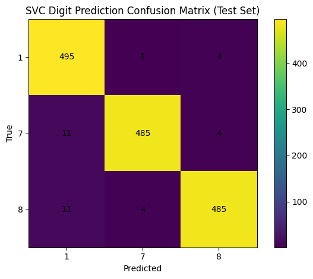

```python
conf_mat = confusion_matrix(yt2, svc_test_pred)
labels = ["1", "7", "8"]

plt.imshow(conf_mat)
for i in range(len(conf_mat)):
    for j in range(len(conf_mat)):
        plt.text(j, i, conf_mat[i, j], ha="center", va="center")
plt.xticks([0, 1, 2], labels)
plt.yticks([0, 1, 2], labels)
plt.xlabel("Predicted")
plt.ylabel("True")
plt.colorbar()
plt.title("SVC Digit Prediction Confusion Matrix (Test Set)")
plt.tight_layout()
```

From reading the confusion matrix :

- The most difficult classes to recognize are 7 and 8 as they both have 15 missclassified samples.
- The easiest class to recognize is 1 as it has only 5 missclassified samples.

In fact, 1 has the simplest shape of all 3 classes this could be an explanation for this result.

#### 3.2.4. Plot some of the sample that are miss-classified. Are they difficult to recognize ? Why did the classifier fail to recognize them?

```python
missed = [i for i in range(len(yt2)) if yt2[i] != svc_test_pred[i]]
missed_rand = np.random.choice(missed, 15)
```

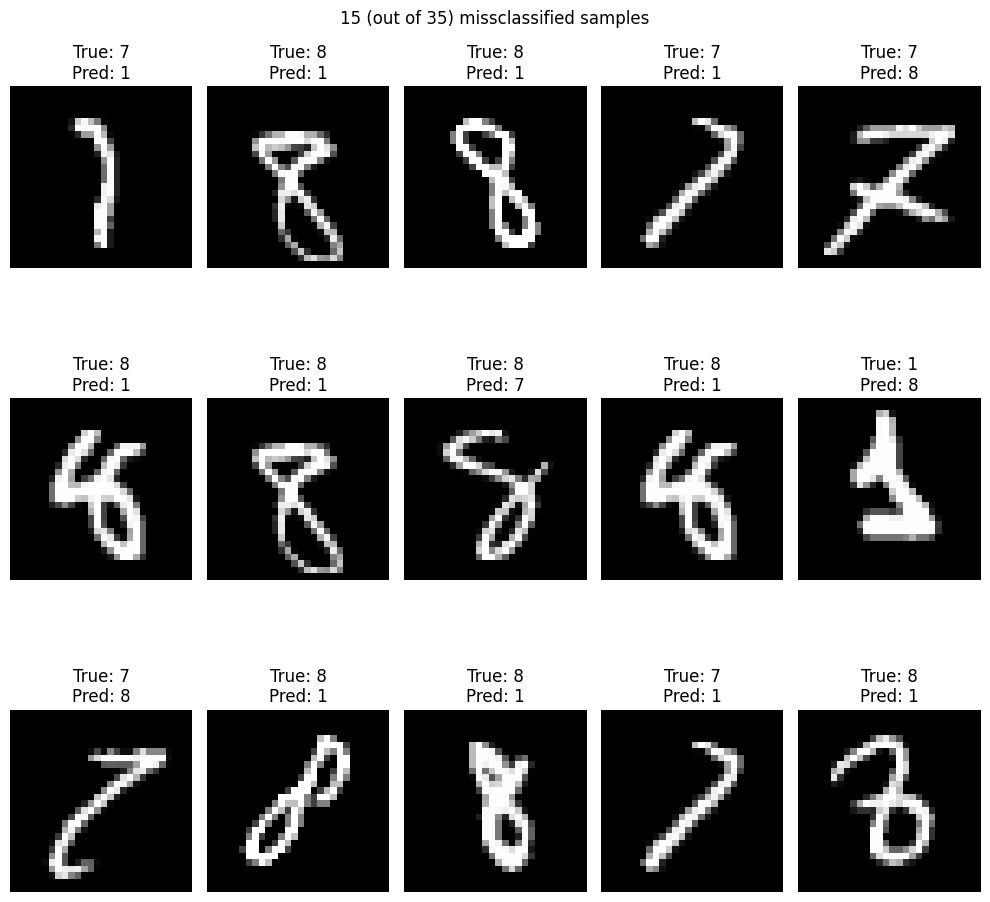

```python
plt.figure(figsize=(10, 10))
for i in range(15):
    plt.subplot(3, 5, i+1)
    plt.imshow(xt2[missed_rand[i]].reshape(28, 28), cmap="gray")
    plt.title("True: "+str(yt2[missed_rand[i]][0])+"\nPred: "+str(svc_test_pred[missed_rand[i]]))
    plt.axis("off")
plt.tight_layout()
plt.suptitle("15 (out of 35) missclassified samples")
plt.show()
```

Many of the above samples are hard to recognize even for a human being. Consequently, it isn't surprising that the classifier failed to recognize them. Others are easier but positionned and structured in an unusual way (curvy 7 predicted as a 8 or stretched 8 predicted as a 1).

Here are my hypothesis as of why the classifier fails on these samples :

- The sample is hard to recognize even for a human being.
- The sample is unusual and the classifier hasn't been trained on such samples (data augmentation or CNN and its translation invariance property could help).

#### 3.2.5. Pick a well classified sample and create 1000 noisy samples of it by adding gaussian noise (np.random.randn). Pick a level of noise that allows you to still distinguish clearly the class. Compute the accuracy of the classifier on those 1000 noisy samples. If the accuracy is 1, increase the noise level or choose another well classified sample.

First, we must pick a well classified sample :

```python
well = [i for i in range(len(yt2)) if yt2[i] == svc_test_pred[i]]
np.random.seed(my_seed)
well_rand_index = np.random.choice(well, 1, )
```

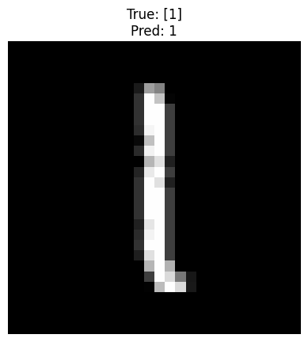

```python
plt.imshow(xt2[well_rand_index[0]].reshape(28, 28), cmap="gray")
plt.title("True: "+str(yt2[well_rand_index[0]])+"\nPred: "+str(svc_test_pred[well_rand_index[0]]))
plt.axis("off")
plt.show()
```

Secondly, we will add gaussian noise to this sample :

```python
n_noisy = 1000
noise_factor = 0.25
noisy_samples = []

for i in range(n_noisy):
    noisy_samples.append(xt2[well_rand_index].reshape(28, 28) + noise_factor * np.random.randn(28, 28))
```

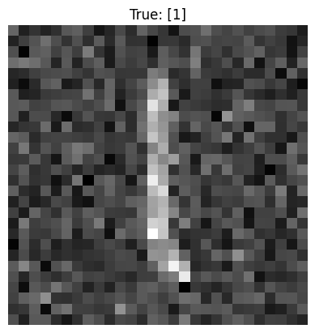

```python
plt.imshow(noisy_samples[0].reshape(28, 28), cmap="gray")
plt.title("True: "+str(yt2[well_rand_index[0]]))
plt.axis("off")
plt.show()
```

```python
noisy_samples = np.array(noisy_samples).reshape(-1, 28*28)
```

```python
svc_pred_noisy = svc.predict(noisy_samples)
svc_acc_noisy = accuracy_score([yt2[well_rand_index][0][0] for i in range(len(svc_pred_noisy))], svc_pred_noisy)
print(f"Accuracy on noisy samples : {str(svc_acc_noisy*100)}%")
```

```
Accuracy on noisy samples : 99.2%
```

#### 3.2.6. How robust is the classifier? Visualise some of those "adversarial" examples when the accuracy on the noisy samples is not 1.

Let's visualize some of the missclassified adversarial examples :

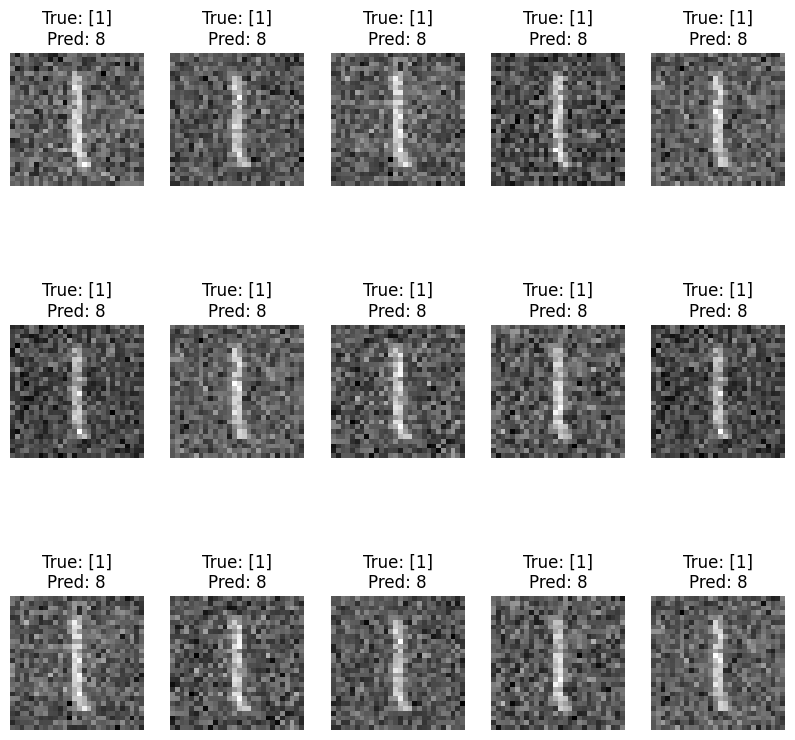

```python
miss_adv = [i for i in range(len(svc_pred_noisy)) if svc_pred_noisy[i] != yt2[well_rand_index][0][0]]
np.random.seed(my_seed)
miss_adv_rand = np.random.choice(miss_adv, 15)

plt.figure(figsize=(10, 10))
for i in range(15):
    plt.subplot(3, 5, i+1)
    plt.imshow(noisy_samples[miss_adv_rand[i]].reshape(28, 28), cmap="gray")
    plt.title("True: "+str(yt2[well_rand_index[0]])+"\nPred: "+str(svc_pred_noisy[miss_adv_rand[i]]))
    plt.axis("off")
```

It seems that the classifier always makes the same mistake with this specific noise ; it classifies the sample as a 8 while it is in fact a 1. This could be explained by the shapes of the digits, the model is used to "1" digits that are in a straight lies while the adversarial examples have noise around.

As a conclusion, our model is relatively robust to gaussian noise adversarial examples. I tested multiple well classified samples and the one that caused the most missclassifications still showed 98.2% accuracy on adversarial examples.

# 4. Convolutionnal Neural Network Bonus

#### 4.1. Implement a CNN and train it on the data (you will need to reshape it to store it as images). Investigate te performance of the CNN when varying its parameters. Does it have better performance than the model above? Is it more robust to adversarial examples?.

##### 4.1.1. Construct the model

```python
x2_im = torch.from_numpy(x2.reshape(-1, 28, 28))
xt2_im = torch.from_numpy(xt2.reshape(-1, 28, 28))

# We only have 3 labels out of the 10 possible ones. We need to map them to 0, 1 and 2
map = {1:0, 7:1, 8:2}
rev_map = {0:1, 1:7, 2:8}

y2_im = torch.tensor([map[i] for i in y2.squeeze(1)])
yt2_im = torch.tensor([map[i] for i in yt2.squeeze(1)])
```

```python
class CNN(nn.Module):
    def __init__(self):
        super(CNN, self).__init__()
        self.conv1 = nn.Conv2d(1, 32, kernel_size=3)
        self.conv2 = nn.Conv2d(32, 64, kernel_size=3)
        self.fc1 = nn.Linear(1600, 128)
        self.fc2 = nn.Linear(128, 3)  # 3 classes

    def forward(self, x):
        x = torch.relu(self.conv1(x))
        x = torch.max_pool2d(x, 2)
        x = torch.relu(self.conv2(x))
        x = torch.max_pool2d(x, 2)
        x = x.view(x.size(0), -1)
        x = torch.relu(self.fc1(x))
        x = self.fc2(x)
        return x

model = CNN()

# Define loss function and optimizer
criterion = nn.CrossEntropyLoss()
optimizer = optim.Adam(model.parameters(), lr=0.001)

# Convert data to torch tensors
train_dataset = TensorDataset(x2_im.unsqueeze(1).float(), y2_im.squeeze().long())
test_dataset = TensorDataset(xt2_im.unsqueeze(1).float(), yt2_im.squeeze().long())

# Create data loaders
batch_size = 64
train_loader = DataLoader(train_dataset, batch_size=batch_size, shuffle=True)
test_loader = DataLoader(test_dataset, batch_size=batch_size, shuffle=False)

# Training loop
num_epochs = 10
for epoch in range(num_epochs):
    model.train()
    for inputs, labels in train_loader:
        optimizer.zero_grad()
        outputs = model(inputs)
        loss = criterion(outputs, labels)
        loss.backward()
        optimizer.step()

    # Evaluation
    model.eval()
    correct = 0
    total = 0
    with torch.no_grad():
        for inputs, labels in test_loader:
            outputs = model(inputs)
            _, predicted = torch.max(outputs.data, 1)
            total += labels.size(0)
            correct += (predicted == labels).sum().item()

    accuracy = 100 * correct / total
    print(f'Epoch {epoch+1}/{num_epochs}, Test Accuracy: {accuracy:.2f}%')
```

[output not shown]

```python
with torch.no_grad():
    test_outputs = model(xt2_im.unsqueeze(1).float())

predicted_labels = torch.argmax(test_outputs, dim=1)
```

```python
cnn_train_pred = torch.argmax(model(x2_im.unsqueeze(1).float()), dim=1).detach().numpy()
cnn_test_pred = torch.argmax(model(xt2_im.unsqueeze(1).float()), dim=1).detach().numpy()

cnn_train_acc, cnn_train_f1, cnn_train_prec, cnn_train_rec = get_acc_f1_prec_rec(y2_im.detach().numpy(), cnn_train_pred)
cnn_test_acc, cnn_test_f1, cnn_test_prec, cnn_test_rec = get_acc_f1_prec_rec(yt2_im.detach().numpy(), cnn_test_pred)

pd.DataFrame({
    "Train Accuracy": [lda_train_acc, logreg_train_acc, svc_train_acc, mlp_train_acc, cnn_train_acc],
    "Test Accuracy": [lda_test_acc, logreg_test_acc, svc_test_acc, mlp_test_acc, cnn_test_acc],
    "Train F1": [lda_train_f1, logreg_train_f1, svc_train_f1, mlp_train_f1, cnn_train_f1],
    "Test F1": [lda_test_f1, logreg_test_f1, svc_test_f1, mlp_test_f1, cnn_test_f1],
    "Train Precision": [lda_train_prec, logreg_train_prec, svc_train_prec, mlp_train_prec, cnn_train_prec],
    "Test Precision": [lda_test_prec, logreg_test_prec, svc_test_prec, mlp_test_prec, cnn_test_prec],
    "Train Recall": [lda_train_rec, logreg_train_rec, svc_train_rec, mlp_train_rec, cnn_train_rec],
    "Test Recall": [lda_test_rec, logreg_test_rec, svc_test_rec, mlp_test_rec, cnn_test_rec]
}, index=["LDA", "LogReg", "SVC", "MLP", "CNN"]).round(2).style.highlight_max(color="purple", axis=0, subset=["Test Accuracy", "Test F1", "Test Precision", "Test Recall"])
```

|  | Train Accuracy | Test Accuracy | Train F1 | Test F1 | Train Precision | Test Precision | Train Recall | Test Recall |
| --- | --- | --- | --- | --- | --- | --- | --- | --- |
| LDA | 0.960000 | 0.950000 | 0.960000 | 0.950000 | 0.960000 | 0.950000 | 0.960000 | 0.950000 |
| LogReg | 1.000000 | 0.970000 | 1.000000 | 0.970000 | 1.000000 | 0.970000 | 1.000000 | 0.970000 |
| SVC | 1.000000 | 0.980000 | 1.000000 | 0.980000 | 1.000000 | 0.980000 | 1.000000 | 0.980000 |
| MLP | 1.000000 | 0.980000 | 1.000000 | 0.980000 | 1.000000 | 0.980000 | 1.000000 | 0.980000 |
| CNN | 1.000000 | 0.990000 | 1.000000 | 0.990000 | 1.000000 | 0.990000 | 1.000000 | 0.990000 |

```python
predicted_labels_remaped = [rev_map[int(i.item())] for i in predicted_labels]
```

```python
print(classification_report(yt2, predicted_labels_remaped))
```

```
              precision    recall  f1-score   support

           1       0.99      0.99      0.99       500
           7       1.00      0.97      0.98       500
           8       0.98      1.00      0.99       500

    accuracy                           0.99      1500
   macro avg       0.99      0.99      0.99      1500
weighted avg       0.99      0.99      0.99      1500
```

After some testing on the models parameters, the above architecture gave the best results and beats the previous models in terms of performances (accuracy-wise).

##### 4.1.2. Adversarial examples

Now that we have a satisfactory model, let's test its robustness to adversarial examples. We will use the same method as before (adding gaussian noise to the sample) :

```python
np.random.seed(my_seed)
well_class_index = np.random.choice([i for i in range(len(yt2)) if yt2_im[i] == predicted_labels[i]], 1)
```

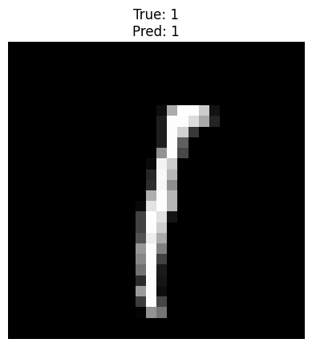

```python
true_class = rev_map[int(yt2_im[well_class_index][0].item())]
plt.imshow(xt2_im[well_class_index][0], cmap="gray")
plt.title("True: "+str(rev_map[int(yt2_im[well_class_index][0].item())])+"\nPred: "+str(rev_map[int(predicted_labels[well_class_index][0].item())]))
plt.axis("off")
plt.show()
```

```python
n_noisy = 1000
noise_factor = 0.25
noisy_samples = []

for i in range(n_noisy):
    np.random.seed(my_seed)
    noisy_samples.append(xt2[well_class_index].reshape(28, 28) + noise_factor * np.random.randn(28, 28))
noisy_samples = torch.from_numpy(np.array(noisy_samples).reshape(-1, 28, 28))
```

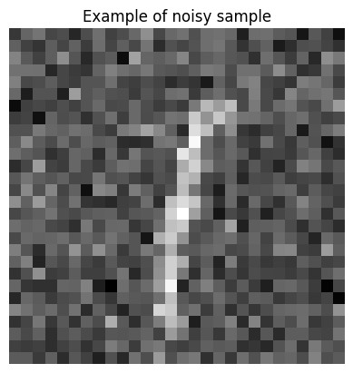

```python
plt.imshow(noisy_samples[0].reshape(28, 28), cmap="gray")
plt.title("Example of noisy sample")
plt.axis("off")
plt.show()
```

```python
with torch.no_grad():
    test_outputs = model(noisy_samples.unsqueeze(1).float())

predicted_noisy_labels = torch.argmax(test_outputs, dim=1)

cnn_acc_noisy = accuracy_score([map[true_class] for i in range(len(predicted_noisy_labels))], predicted_noisy_labels)
print(f"Accuracy on noisy samples : {str(cnn_acc_noisy*100)}%")
```

```
Accuracy on noisy samples : 100.0%
```

```python
predicted_noisy_labels
```

[output not shown]

[output cut: 27 more lines]

To conclude, even if we didn't find adversarial examples for this model, it doesn't mean that there isn't. With more time put in we could probably find some adversarial examples for this model.

# 5. Discussion

This last practical session was my favorite, in terms of new knowledges, topics and applicability to the real word.

As a last word, this course genuinely helped me to understand the actual mechanisms behind machine learning. I feel much more confident in my ability to use machine learning in the future.